# Practical Machine Learning Project

Laura Robledo

31/07/2020

# Predicting “how well” an activity has been done by using data obtained from Human Activity Recognition systems

## Summary

The goal of this project is to create a model to predict if an exercise has been done properly based on the data collected from different sensors.

For this, we will be using data on six young healthy male participants aged between 20-28 years that were asked to perform one set of 10 repetitions of the Unilateral Dumbbell Biceps Curl in five different fashions: **Class A** – Exactly according to the specification  
**Class B** – Throwing the elbows to the front  
**Class C** – Lifting the dumbbell only halfway  
**Class D** – Lowering the dumbbell only halfway  
**Class E** – Throwing the hips to the front

## Data

Training data:

https://d396qusza40orc.cloudfront.net/predmachlearn/pml-training.csv

Test data:

https://d396qusza40orc.cloudfront.net/predmachlearn/pml-testing.csv

Ugulino, W.; Cardador, D.; Vega, K.; Velloso, E.; Milidiu, R.; Fuks, H. Wearable Computing: Accelerometers’ Data Classification of Body Postures and Movements. Proceedings of 21st Brazilian Symposium on Artificial Intelligence. Advances in Artificial Intelligence - SBIA 2012. In: Lecture Notes in Computer Science. , pp. 52-61. Curitiba, PR: Springer Berlin / Heidelberg, 2012. ISBN 978-3-642-34458-9. DOI: 10.1007/978-3-642-34459-6_6.

Read more: http://groupware.les.inf.puc-rio.br/har#ixzz6TfIvKmk7  
http://groupware.les.inf.puc-rio.br/har#ixzz6TfJHbAHG

## Data Manipulation

Only the columns with information regarding the metrics obtained by the sensors and the class of the activity have been kept:

```r
names(pml_testing)
```

```
##  [1] "roll_belt"            "pitch_belt"           "yaw_belt"
##  [4] "total_accel_belt"     "gyros_belt_x"         "gyros_belt_y"
##  [7] "gyros_belt_z"         "accel_belt_x"         "accel_belt_y"
## [10] "accel_belt_z"         "magnet_belt_x"        "magnet_belt_y"
## [13] "magnet_belt_z"        "roll_arm"             "pitch_arm"
## [16] "yaw_arm"              "total_accel_arm"      "gyros_arm_x"
## [19] "gyros_arm_y"          "gyros_arm_z"          "accel_arm_x"
## [22] "accel_arm_y"          "accel_arm_z"          "magnet_arm_x"
## [25] "magnet_arm_y"         "magnet_arm_z"         "roll_dumbbell"
## [28] "pitch_dumbbell"       "yaw_dumbbell"         "total_accel_dumbbell"
## [31] "gyros_dumbbell_x"     "gyros_dumbbell_y"     "gyros_dumbbell_z"
## [34] "accel_dumbbell_x"     "accel_dumbbell_y"     "accel_dumbbell_z"
## [37] "magnet_dumbbell_x"    "magnet_dumbbell_y"    "magnet_dumbbell_z"
## [40] "roll_forearm"         "pitch_forearm"        "yaw_forearm"
## [43] "total_accel_forearm"  "gyros_forearm_x"      "gyros_forearm_y"
## [46] "gyros_forearm_z"      "accel_forearm_x"      "accel_forearm_y"
## [49] "accel_forearm_z"      "magnet_forearm_x"     "magnet_forearm_y"
## [52] "magnet_forearm_z"     "problem_id"
```

## Training and testing sets/Cross-referencing

70% of the data was used for the training data set, the rest was allocated to the testing data set.

```r
set.seed(1)
inTrain <- createDataPartition(pml_training$classe, p = 0.7, list = FALSE)
trainData <- pml_training[inTrain, ]
testData <- pml_training[-inTrain, ]
dim(trainData)
```

```
## [1] 13737    52
```

```r
dim(testData)
```

```
## [1] 5885   52
```

## Exploratory plots

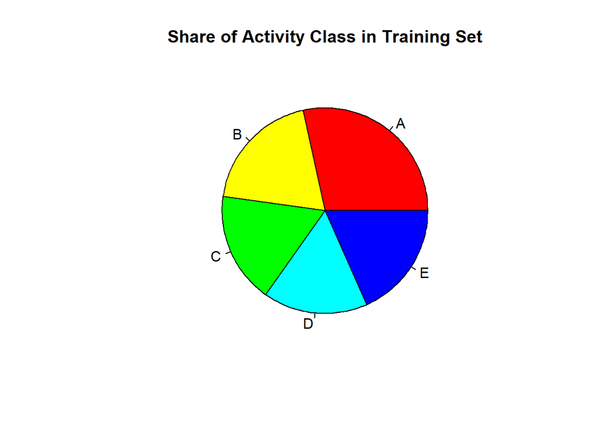

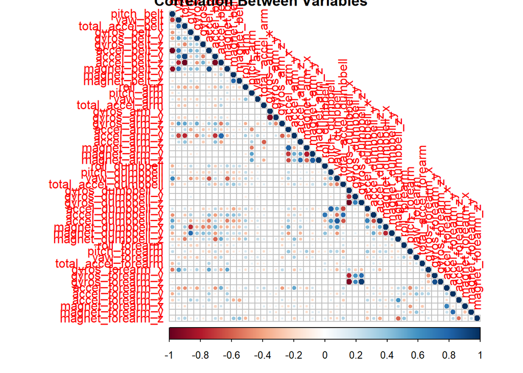

From the correlation plot we can see that there are only a few variables that have strong correlations.

## Prediction models

Three different models were compared:  
– Random Forests (“rf”)  
– Boosted Trees (“gbm”)  
– Linear Discriminant analysis (“lda”)

Finally, the predictions are Stacked together using random forests (“rf”).

```r
mod_rf <- train(classe ~ ., data = trainData, method = "rf") #Creating models
mod_gbm <- train(classe ~ ., data = trainData, method = "gbm")
mod_lda <- train(classe ~ ., data = trainData, method = "lda")
pred_rf <- predict(mod_rf, testData) #Testing models using test dataset
pred_gbm <- predict(mod_gbm, testData)
pred_lda <- predict(mod_lda, testData)

predDF <- data.frame(pred_rf, pred_gbm, pred_lda, classe = testData$classe) #combine models & predict
combModFit <- train(classe ~ ., method = "rf", data = predDF)
combPred <- predict(combModFit, predDF)
```

# Measure Accuracy in the Models

```r
#Random Forest
round(confusionMatrix(pred_rf, as.factor(testData$classe))$overall[1],2)
```

```
## Accuracy
##     0.99
```

```r
#Boosted Trees
round(confusionMatrix(pred_gbm, as.factor(testData$classe))$overall[1],2)
```

```
## Accuracy
##     0.96
```

```r
#Linear Discriminant analysis
round(confusionMatrix(pred_lda, as.factor(testData$classe))$overall[1],2)
```

```
## Accuracy
##     0.68
```

```r
#combined
round(confusionMatrix(combPred, as.factor(testData$classe))$overall[1],2)
```

```
## Accuracy
##     0.99
```

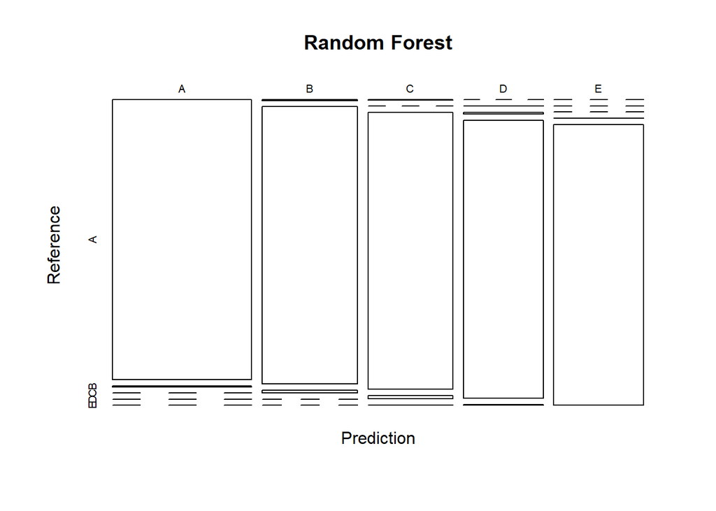

## Calculating Out of Sample Error

```r
dim(testData)
```

```
## [1] 5885   52
```

```r
prediction <- predict(mod_rf, newdata=testData)
length(prediction)
```

```
## [1] 5885
```

```r
round(100*(1-sum(prediction == testData$classe)/length(prediction)),2)
```

```
## [1] 0.8
```

The out of sample error is expected to be around 0.8%

## Prediction 20 cases (Quiz)

Finally, the original test data provided for testing is used to create the predictions for the quiz.

```r
predict(mod_gbm, newdata=pml_testing)
```

```
##  [1] B A B A A E D B A A B C B A E E A B B B
## Levels: A B C D E
```